[OHI British Columbia](http://www.ohibc.org/) | [OHI Science](http://ohi-science.org) | [Citation policy](https://github.com/OHI-Science/ohiprep/releases)

# Set up ocean area raster and MPA pct dataframe

Compiled on Sat Jun 16 21:19:20 2018 by ohara

```r
knitr::opts_chunk$set(fig.width = 6, fig.height = 4, fig.path = 'Figs/',
                      echo = TRUE, message = FALSE, warning = FALSE)

library(raster)
library(sf)
library(fasterize)

source('~/github/src/R/common.R')  ###
  ### includes library(tidyverse); library(stringr); dir_M points to ohi directory

dir_git <- '~/github/spp_risk_dists'

### goal specific folders and info
dir_setup   <- file.path(dir_git, 'data_setup')
dir_spatial <- file.path(dir_git, 'spatial')
dir_anx     <- file.path(dir_M, 'git-annex')
dir_o_anx   <- file.path(dir_O, 'git-annex/spp_risk_dists')
# ### provenance tracking
library(provRmd); prov_setup()

### support scripts
source('~/github/src/R/rast_tools.R')
  ### raster plotting and analyzing scripts

ocean_base <- raster(file.path(dir_M, 'git-annex/globalprep/spatial/ocean.tif'))
### Note: this claims to have values 0 to 255...
```

# 1 Summary

To define spatial areas more accurately, create rasters of WDPA and ocean area at CHI resolution (934m Mollweide). These can then be resampled/aggregated back to tenth degree working rasters, summing the total ocean area and total protected area within each working cell.

- Ocean area - use ocean area raster from CHI and/or OHI as base for all other rasters
- LOICZID masked to ocean areas only
  - Raster values = protection level

# 2 Data Sources

### 2.0.1 WDPA

# 3 Methods

## 3.1 Ocean area raster

Use ocean raster from OHI assessments, match to 0.10 degree raster, crosstab to sum area in each 0.10 degree cell, then make a new raster of that… * note that area calculations for very northward cells may disagree due to weird geometry; replace only cells below 84°N (all above that should be pure ocean). Compare value in ocean-only cells at various latitudes though to understand approximation error - approaching equator should be very close. * this will be used to roughly calculate proportion of protected area in each tenth-degree cell; estimation error of MPA coverage should probably err in the same direction as total ocean area error.

### 3.1.1 Create a tenth-degree cell raster to match CHI base raster

```r
tenthdeg_ids_rast <- raster::raster(resolution = 0.10, ext = extent(c(-180, 180, -90, 90)))
### default to WGS84
values(tenthdeg_ids_rast) <- 1:length(tenthdeg_ids_rast)

tenthdeg_moll_file    <- file.path(dir_o_anx, 'spatial/tenthdeg_moll_ocean_934m.tif')
tenthdeg_moll_id_file <- file.path(dir_o_anx, 'spatial/tenthdeg_moll_id_934m.tif')

if(!file.exists(tenthdeg_moll_file)) {
  ### create bounding polygon for cropping the ID raster; use sp:: for interaction with raster
  globe_extents <- data.frame(long = rep(-180, times = 1801), lat = seq(-90, 90, .1)) %>%
    bind_rows(data.frame(long = seq(-180, 180, .1), lat = rep(90, times = 3601))) %>%
    bind_rows(data.frame(long = rep(180, times = 1801), lat = seq(90, -90, -.1))) %>%
    bind_rows(data.frame(long = seq(180, -180, -.1), lat = rep(-90, times = 3601))) %>%
    as.matrix()

  globe_poly <- sp::Polygon(globe_extents) %>% list(.) %>%
    sp::Polygons(., 1) %>% list(.) %>%
    sp::SpatialPolygons(., proj4string = raster::crs(tenthdeg_rast)) %>%
    sp::spTransform(., raster::crs(ocean_base))

  globe_poly_sf <- globe_poly %>% st_as_sf()
  globe_rast <- fasterize(globe_poly_sf, ocean_base)
  # plot(globe_poly)
  # plot(tenthdeg_moll)

  ### project the 0.10 deg lat-long raster to 934m Mollweide raster; mask with
  ### the globe polygon
  tenthdeg_moll <- projectRaster(from     = tenthdeg_rast,
                                 to       = ocean_base,
                                 progress = 'text',
                                 method   = 'ngb') %>%
    raster::mask(., globe_rast,
                 filename = tenthdeg_moll_id_file,
                 overwrite = TRUE)


  ### mask to just ocean cells based on Cumulative Impacts ocean raster
  tenthdeg_moll_ocean <- raster::mask(tenthdeg_moll, ocean_base,
                                      filename = tenthdeg_moll_file,
                                      overwrite = TRUE)
}

git_prov(tenthdeg_moll_id_file, 'output') ### mask() won't check provenance
git_prov(tenthdeg_moll_file, 'output')    ### mask() won't check provenance
```

### 3.1.2 Aggregate ocean area back to 0.10° raster

Area calculation in this manner has some error to it; but if we calculate a proportion then multiply it by the values from the `raster::area()` function later we should get fairly close approximation to ocean area.

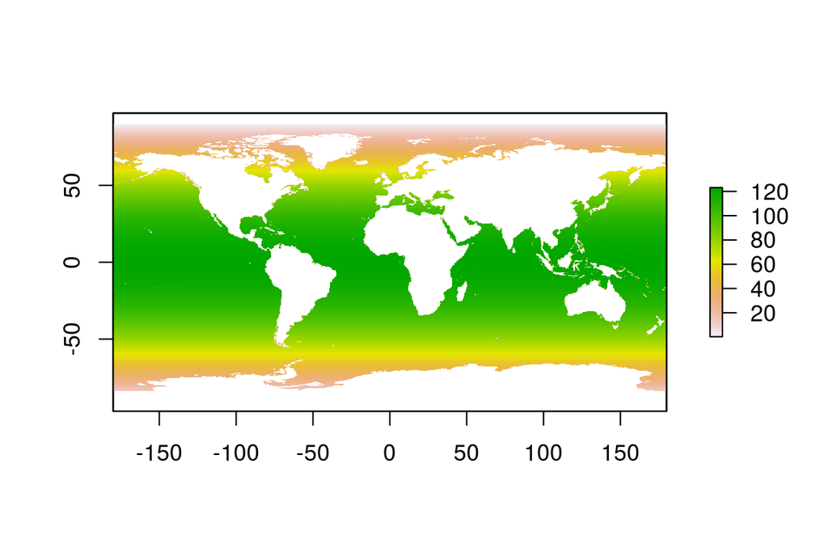

```r
tenthdeg_moll_ocean <- raster(tenthdeg_moll_file)
tenthdeg_moll_ids   <- raster(tenthdeg_moll_id_file)

tenthdeg_ocean_area_file <- file.path(dir_git, 'spatial', 'ocean_area_rast_010_wgs84.tif')

if(!file.exists(tenthdeg_ocean_area_file)) {

  # reso_km2 <- raster::res(tenthdeg_moll_ocean)[1] / 1000

  tenthdeg_ocean_df <- data.frame(cell_id  = values(tenthdeg_moll_ids),
                                  ocean_id = values(tenthdeg_moll_ocean))

  tenthdeg_area_df <- tenthdeg_ocean_df %>%
    group_by(cell_id) %>%
    summarize(total_cells = n(),
              ocean_cells = sum(!is.na(ocean_id))) %>%
    mutate(ocean_area_prop = ocean_cells / total_cells)

  tenthdeg_rast_area <- data.frame(cell_id = values(tenthdeg_rast),
                                   cell_area_km2 = values(area(tenthdeg_rast)))

  ### above 84°N, set ocean area proportion to 1; below 84°S, set to 0.
  tenthdeg_area_df2 <- tenthdeg_area_df %>%
    full_join(tenthdeg_rast_area, by = 'cell_id') %>%
    mutate(ocean_area_prop = ifelse(cell_id < 216000,  1, ocean_area_prop),
           ocean_area_prop = ifelse(cell_id > 6264000, 0, ocean_area_prop),
           ocean_area_km2 = cell_area_km2 * ocean_area_prop) %>%
    select(cell_id, ocean_area_prop, cell_area_km2, ocean_area_km2) %>%
    filter(ocean_area_prop > 0)

  tenthdeg_area_rast <- tenthdeg_rast %>%
    subs(tenthdeg_area_df2, which = 'ocean_area_km2', by = 'cell_id')
  # plot(tenthdeg_area_rast)
  writeRaster(tenthdeg_area_rast, tenthdeg_ocean_area_file, overwrite = TRUE)

} else {
  git_prov(tenthdeg_ocean_area_file, 'output')
}

plot(raster(tenthdeg_ocean_area_file))
```

## 3.2 Create WDPA MPA percent protection data frame

Because we are rasterizing the protected areas down to the CHI raster resolution, we risk dropping any MPAs smaller than about 1 km^2. We assume these are not likely to have a significant impact on biodiversity protection.

### 3.2.1 Create WDPA map at Mollweide 934m resolution

```r
tenthdeg_moll_ocean <- raster(tenthdeg_moll_file)

wdpa_marine_file  <- file.path(dir_o_anx, 'wdpa/wdpa_mar_by_cat_jun2018.tif')

if(!file.exists(wdpa_marine_file)) {

  wdpa_poly <- read_sf(file.path(dir_o_anx, 'wdpa/wdpa_jun2018/WDPA_June2018-shapefile-polygons.shp'))

  # wdpa_poly$IUCN_CAT %>% unique()
  iucn_cats <- c('Ia'  = 1,
                 'Ib'  = 1,
                 'II'  = 2,
                 'III' = 3,
                 'IV'  = 4,
                 'V'   = 5,
                 'VI'  = 6)
  # wdpa_poly$STATUS %>% table()
       # Adopted   Designated  Established    Inscribed Not Reported     Proposed
       #      34       215853            2          241          128         1537
  # wdpa_poly$NO_TAKE %>% unique()
  # x <- wdpa_poly %>% filter(NO_TAKE %in% c('All', 'Part'))

  wdpa_marine <- wdpa_poly %>%
    filter(MARINE > 0 | GIS_M_AREA > 0) %>%
    filter(STATUS %in% c('Designated', 'Adopted', 'Established')) %>%
      ### no paper parks
    filter(!str_detect(tolower(MANG_PLAN), 'non-mpa')) %>%
      ### omit non-MPA fisheries or species management plans
    mutate(no_take = (NO_TAKE == 'All') | (NO_TAKE == 'Part' & NO_TK_AREA > 0.75 * GIS_M_AREA),
             ### if NO_TK_AREA is 75% or more of GIS area, count it...
           cat = iucn_cats[IUCN_CAT],
           cat = ifelse(no_take & !cat %in% 1:2, 7, cat), ### use 7 as a "no take" flag
           cat = ifelse(is.na(cat), -1, cat)) %>%         ### use -1 as an "other protected" flag
    arrange(cat) %>%
    st_transform(crs = proj4string(ocean_base))

  wdpa_all_rast <- fasterize::fasterize(sf     = wdpa_marine,
                                        raster = ocean_base,
                                        field  = 'cat',
                                        fun    = 'first')

  x <- mask(wdpa_all_rast, tenthdeg_moll_ocean,
            filename = wdpa_marine_file,
            overwrite = TRUE)
}

git_prov(file.path(dir_o_anx, 'wdpa/wdpa_jun2018/WDPA_June2018-shapefile-polygons.shp'), 'input')
git_prov(wdpa_marine_file, 'output') ### even in "if", mask() won't prov-register it.
```

### 3.2.2 Crosstab WDPA map to cell IDs

Be cautious when using `raster::crosstab()` as it returns factors that need to be coerced into integers… This code results in a file of cell IDs, IUCN protected area categories (1 = Ia and Ib, 2-6 = II - VI, 7 = no take, -1 = other), and proportion of cell protected by that category.

```r
# wdpa_marine_file  <- file.path(dir_o_anx, 'wdpa/wdpa_mar_by_cat_jun2018.tif')
# tenthdeg_moll_file <- file.path(dir_o_anx, 'spatial/tenthdeg_moll_id_934m.tif')
# tenthdeg_ocean_area_file <- file.path(dir_git, 'spatial', 'ocean_area_rast_010_wgs84.tif')

wdpa_all_rast       <- raster(wdpa_marine_file)
tenthdeg_moll_ocean_rast <- raster(tenthdeg_moll_file)
tenthdeg_area_rast  <- raster(tenthdeg_ocean_area_file)

wdpa_cell_area_file <- file.path(dir_git, 'spatial/wdpa_mpa_area_010_wgs84.csv')

if(!file.exists(wdpa_cell_area_file)) {
  ### Break into smaller chunks for faster processing and eventual parallelizing
  n_chunks <- 30

  crosstab_chunk <- function(rast1, rast2, chunk, n_chunks) {
    ### chunk <- 1
    chunk_size <- ncol(rast1) / n_chunks
    left_bound <- (chunk - 1) * chunk_size + 1

    chunk_ext <- extent(rast1, 1, nrow(rast1), left_bound, left_bound + chunk_size)
    message('Processing ', chunk, ': ', paste0(as.character(round(chunk_ext)), collapse = ', '))
    wdpa_chunk    <- crop(rast1, chunk_ext)
    cell_id_chunk <- crop(rast2, chunk_ext)

    wdpa_cells <- crosstab(wdpa_chunk, cell_id_chunk,
                                    progress = 'text',
                                    long = TRUE) %>%
      setNames(c('wdpa_category', 'cell_id', 'n_prot')) %>%
      mutate(wdpa_category = as.integer(as.character(wdpa_category)),
             cell_id       = as.integer(as.character(cell_id)))
        ### wdpa_category and cell_id are crosstabbed as factors - first
        ### convert to character (to unfactorize it) then to integer.  Otherwise
        ### you end up with factor index, not actual cell ID or category.

    return(wdpa_cells)
  }

  system.time({
    wdpa_cells_list <- parallel::mclapply(1:n_chunks,
                                          FUN = function(x) crosstab_chunk(wdpa_all_rast,
                                                                           tenthdeg_moll_ocean_rast,
                                                                           chunk = x, n_chunks),
                                          mc.cores = 12)
  #     user   system  elapsed
  # 1221.984 1340.792  410.808
  })

  wdpa_cells_df <- bind_rows(wdpa_cells_list)

  tenthdeg_area_df <- data.frame(cell_id  = values(tenthdeg_ids_rast),
                                 area_km2 = values(tenthdeg_area_rast))

  reso_km2 <- raster::res(tenthdeg_moll_ocean_rast)[1] / 1000

  wdpa_area_df <- wdpa_cells_df %>%
    full_join(tenthdeg_area_df) %>%
    filter(!is.na(wdpa_category)) %>%
    mutate(prot_area_km2 = n_prot * reso_km2^2,
           mpa_pct = prot_area_km2 / area_km2) %>%
    select(wdpa_category, cell_id, mpa_pct)

  write_csv(wdpa_area_df, wdpa_cell_area_file)

} else {
  git_prov(wdpa_cell_area_file, 'output')
}
```

### 3.2.3 View WDPA protected area proportions as raster

Proportional protection can be multiplied by ocean area raster to get area of protection. Collect by category (to avoid duplicate “by” values):

Note: these are not saved as rasters at this point… they are easily created from the dataframe of cell ID to protected proportion.

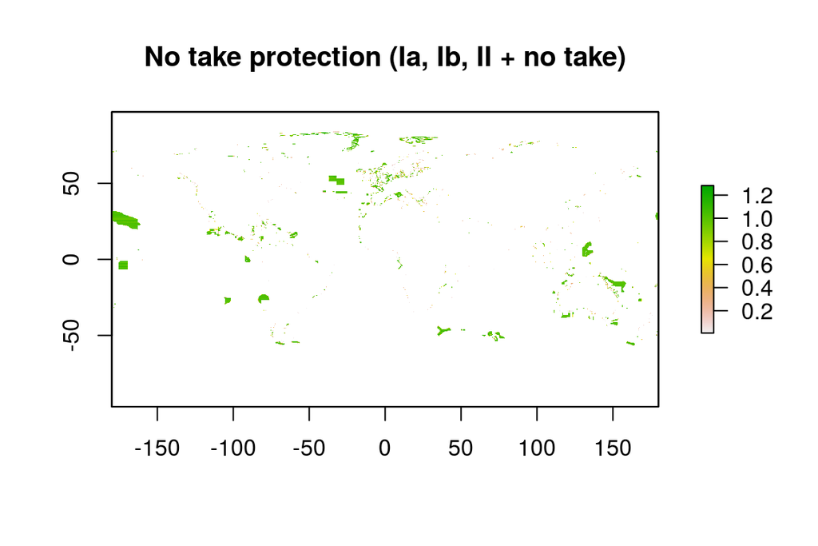

```r
wdpa_area_df <- read_csv(wdpa_cell_area_file)

# tenthdeg_ids_rast <- raster::raster(resolution = 0.10, ext = extent(c(-180, 180, -90, 90)))
# ### default to WGS84
# values(tenthdeg_ids_rast) <- 1:length(tenthdeg_rast)

notake_df <- wdpa_area_df %>%
  filter(wdpa_category <= 2) %>%
  group_by(cell_id) %>%
  summarize(mpa_pct = sum(mpa_pct))

conservation_df <- wdpa_area_df %>%
  filter(wdpa_category <= 4) %>%
  group_by(cell_id) %>%
  summarize(mpa_pct = sum(mpa_pct))

all_prot_df <- wdpa_area_df %>%
  group_by(cell_id) %>%
  summarize(mpa_pct = sum(mpa_pct))

notake_raster <- subs(tenthdeg_ids_rast, notake_df, by = 'cell_id', which = 'mpa_pct')
plot(notake_raster, main = 'No take protection (Ia, Ib, II + no take)')
```

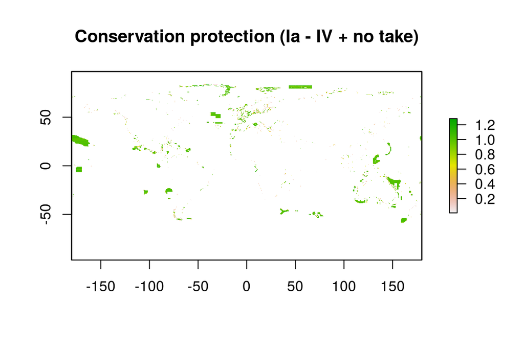

```r
conservation_raster <- subs(tenthdeg_ids_rast, conservation_df, by = 'cell_id', which = 'mpa_pct')
plot(conservation_raster, main = 'Conservation protection (Ia - IV + no take)')
```

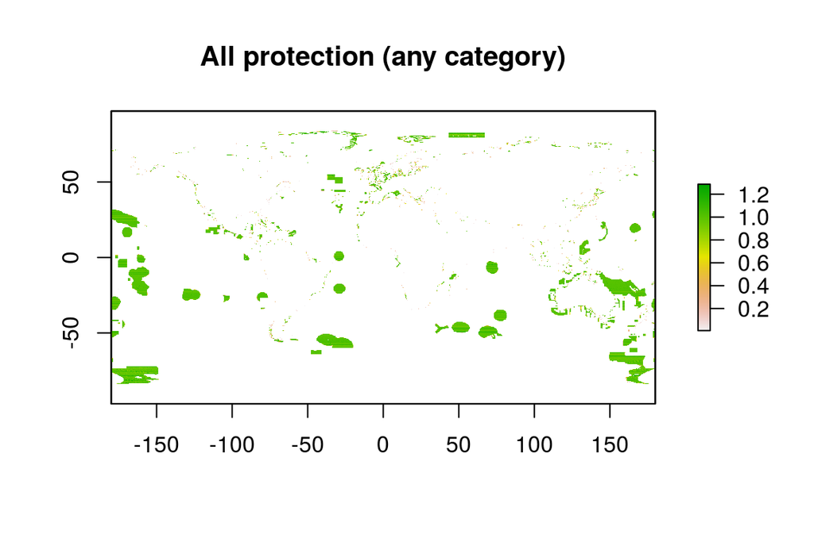

```r
all_prot_raster <- subs(tenthdeg_ids_rast, all_prot_df, by = 'cell_id', which = 'mpa_pct')
plot(all_prot_raster, main = 'All protection (any category)')
```

```r
prov_wrapup(commit_outputs = FALSE)
```

# 4 Provenance

- *Run ID: 1 (92749c7); run tag: “standard run”*
- *Run elapsed time: 163.959 seconds; run memory usage: 10844.3 MB*
- *System info:*
  - *System: Linux, Release: 4.4.0-112-generic. Machine: x86_64. User: ohara.*
  - *R version: R version 3.4.4 (2018-03-15), Platform: x86_64-pc-linux-gnu, Running under: Ubuntu 14.04.5 LTS.*
  - *Attached base packages: stats, graphics, grDevices, utils, datasets, methods, base*
  - *Other attached packages: bindrcpp_0.2, provRmd_0.1.1, stringr_1.2.0, RColorBrewer_1.1-2, dplyr_0.7.2, purrr_0.2.3, readr_1.1.0, tidyr_0.7.0, tibble_1.3.4, ggplot2_2.2.1.9000, tidyverse_1.1.1, fasterize_0.1.0, sf_0.6-1, raster_2.5-8, sp_1.2-5*

[figure not shown]

| sequence | file_name | parent_chunk | file_dir | filetype | uncomm_chgs | commit_hash_short |
| --- | --- | --- | --- | --- | --- | --- |
| 0 | 4_set_up_ocean_area_and_mpa_pct.Rmd | prov_footer | ~/github/spp_risk_dists/data_setup | parent_script | False | fa4c4ef |
| 0 | 4_set_up_ocean_area_and_mpa_pct.Rmd#crosstab_mpa_areas | crosstab_mpa_areas | ~/github/spp_risk_dists/data_setup | parent_chunk | False | fa4c4ef |
| 0 | 4_set_up_ocean_area_and_mpa_pct.Rmd#project_wdpa_to_mollweide | project_wdpa_to_mollweide | ~/github/spp_risk_dists/data_setup | parent_chunk | False | fa4c4ef |
| 0 | 4_set_up_ocean_area_and_mpa_pct.Rmd#prov_footer | prov_footer | ~/github/spp_risk_dists/data_setup | parent_chunk | False | fa4c4ef |
| 0 | 4_set_up_ocean_area_and_mpa_pct.Rmd#reproject_loiczid_to_mollweide | reproject_loiczid_to_mollweide | ~/github/spp_risk_dists/data_setup | parent_chunk | False | fa4c4ef |
| 0 | 4_set_up_ocean_area_and_mpa_pct.Rmd#setup | setup | ~/github/spp_risk_dists/data_setup | parent_chunk | False | fa4c4ef |
| 0 | 4_set_up_ocean_area_and_mpa_pct.Rmd#unnamed-chunk-1 | unnamed-chunk-1 | ~/github/spp_risk_dists/data_setup | parent_chunk | False | fa4c4ef |
| 0 | 4_set_up_ocean_area_and_mpa_pct.Rmd#unnamed-chunk-2 | unnamed-chunk-2 | ~/github/spp_risk_dists/data_setup | parent_chunk | False | fa4c4ef |
| 1 | rast_tools.R | setup | ~/github/src/R | sourced_script |  |  |
| 2 | ocean.tif | setup | /home/shares/ohi/git-annex/globalprep/spatial | input |  |  |

[output cut: 14 more lines]